# Predicting Player Spending Behavior and Profitability in Mobile Games

Author

Yuxi Wang

## 1. Introduction

Mobile gaming is one of the fastest-growing and most profitable segments of the global entertainment market. Revenue in this space is highly concentrated: a small percentage of so-called “whale” users contribute a disproportionately large share of total spending. Understanding what drives players to spend — and whether that behavior can be predicted — has become a critical question for game studios seeking to optimize monetization strategies, improve retention, and forecast revenue.

This project is motivated by two guiding research questions:

- **Q1:** Which behavioral features are most strongly associated with players’ in-app spending?
- **Q2:** Do spending levels differ across game genres, countries, and payment methods?

To answer these questions, I develop a suite of machine learning models — including Lasso regression, decision trees, random forests, XGBoost, and logistic regression — trained on a dataset of over 3,000 simulated mobile-game players. I also use SHAP values to interpret model behavior and identify the features that most influence spending outcomes.

The results show that accurately predicting individual spending is challenging due to noisy behavioral signals, but consistent group-level patterns emerge — particularly around payment readiness, purchase recency, and early-lifecycle behavior — that can directly inform monetization strategy.

## 2. Setup: Imports and Data Loading

```python
import pandas as pd
import numpy as np
import seaborn as sns
import matplotlib
import matplotlib.pyplot as plt
from plotnine import *

from sklearn.preprocessing import StandardScaler
from sklearn.cluster import KMeans
from sklearn.model_selection import train_test_split
from sklearn.linear_model import LinearRegression, LassoCV, LogisticRegression
from sklearn.metrics import (mean_absolute_error, mean_squared_error, r2_score,
                             confusion_matrix, classification_report,
                             ConfusionMatrixDisplay, accuracy_score,
                             roc_curve, roc_auc_score)
from sklearn.pipeline import Pipeline
from sklearn.impute import SimpleImputer
from sklearn.compose import ColumnTransformer
from sklearn.ensemble import RandomForestRegressor
from sklearn.tree import DecisionTreeRegressor, plot_tree

import xgboost as xgb
import shap
from IPython.display import display

matplotlib.rcParams['figure.dpi'] = 100
```

### 2.1 Load and Inspect the Dataset

```python
df = pd.read_csv(
    "~/Desktop/ND/Section 2/Machine Learning/Project/mobile_game_inapp_purchases.csv",
    encoding='latin-1'
)

print(f"Raw dataset shape: {df.shape}")
print(f"\nColumns:\n{df.columns.tolist()}")
print(f"\nMissing values per column:\n{df.isnull().sum()[df.isnull().sum() > 0]}")
```

```
Raw dataset shape: (3024, 13)

Columns:
['UserID', 'Age', 'Gender', 'Country', 'Device', 'GameGenre', 'SessionCount', 'AverageSessionLength', 'SpendingSegment', 'InAppPurchaseAmount', 'FirstPurchaseDaysAfterInstall', 'PaymentMethod', 'LastPurchaseDate']

Missing values per column:
Age                               60
Gender                            60
Country                           60
Device                            60
GameGenre                         60
InAppPurchaseAmount              136
FirstPurchaseDaysAfterInstall    136
PaymentMethod                    136
LastPurchaseDate                 136
dtype: int64
```

The raw dataset contains **3,024 player records** and 13 columns covering demographics, gameplay behavior, payment information, and spending amounts.

### 2.2 Handle Missing Values

```python
# Drop rows with missing values in essential categorical fields
df.dropna(subset=['Age', 'Gender', 'Country', 'Device', 'GameGenre'], inplace=True)

# Fill remaining missings
df['InAppPurchaseAmount'] = pd.to_numeric(df['InAppPurchaseAmount'], errors='coerce').fillna(0)
df['FirstPurchaseDaysAfterInstall'].fillna(0, inplace=True)
df['PaymentMethod'].fillna('None', inplace=True)

print(f"Dataset after cleaning: {df.shape[0]} rows, {df.shape[1]} columns")
```

```
Dataset after cleaning: 2733 rows, 13 columns
```

After removing observations with missing values in key behavioral or demographic fields, the final dataset contains **2,733 valid samples**, which serve as the basis for all modeling.

**Variable Descriptions:**

| Variable | Description |
| --- | --- |
| `UserID` | Unique player identifier (dropped before modeling) |
| `Age` | Player age in years |
| `Gender` | Player gender identity |
| `Country` | Player’s country of origin |
| `Device` | Mobile platform (iOS / Android) |
| `GameGenre` | Primary game genre played |
| `SessionCount` | Number of gaming sessions |
| `AverageSessionLength` | Average session duration in minutes |
| `SpendingSegment` | Pre-labeled spending classification |
| `InAppPurchaseAmount` | Total purchase amount in USD (regression target) |
| `FirstPurchaseDaysAfterInstall` | Days from install to first purchase |
| `PaymentMethod` | Preferred payment method |
| `LastPurchaseDate` | Timestamp of most recent purchase |

## 3. Feature Engineering

Feature engineering translates raw behavioral signals into model-ready predictors, informed by patterns identified in prior monetization research.

### 3.1 Temporal Features

```python
# Convert purchase date and compute days since last purchase
df['LastPurchaseDate'] = pd.to_datetime(df['LastPurchaseDate'], errors='coerce')
df['DaysSinceLastPurchase'] = (df['LastPurchaseDate'].max() - df['LastPurchaseDate']).dt.days
df['DaysSinceLastPurchase'].fillna(df['DaysSinceLastPurchase'].mean(), inplace=True)

# Drop columns not used in modeling
df.drop(columns=['LastPurchaseDate', 'UserID'], inplace=True, errors='ignore')
```

`DaysSinceLastPurchase` captures purchase recency: how long ago a player last made an in-app purchase. Prior research (Sifa et al., 2015) identifies recency as a strong predictor of future purchase behavior.

### 3.2 Engagement and Spending Intensity Features

```python
# Engagement = total play activity (sessions × duration)
df['EngagementScore'] = df['SessionCount'] * df['AverageSessionLength']

# Per-session spending intensity (used for EDA only, excluded from modeling)
df['AvgSpendPerSession'] = df['InAppPurchaseAmount'] / (df['SessionCount'] + 1)

# Log-transform spending to reduce heavy right skew
df['log_spend'] = np.log1p(df['InAppPurchaseAmount'])

print("Engineered features added: EngagementScore, AvgSpendPerSession, log_spend")
print(df[['EngagementScore', 'AvgSpendPerSession', 'log_spend']].describe().round(3))
```

```
Engineered features added: EngagementScore, AvgSpendPerSession, log_spend
       EngagementScore  AvgSpendPerSession  log_spend
count         2733.000            2733.000   2733.000
mean           201.506               9.520      2.618
std            108.547              44.075      1.565
min             11.010               0.000      0.000
25%            115.960               0.455      1.812
50%            186.200               1.035      2.523
75%            271.520               1.766      2.922
max            636.460             729.718      8.510
```

- **`EngagementScore`** = `SessionCount × AverageSessionLength` — captures total gameplay activity.
- **`AvgSpendPerSession`** = `InAppPurchaseAmount / SessionCount` — measures spending intensity per visit. This feature is excluded from model training since it is directly derived from the outcome variable.
- **`log_spend`** = `log(1 + InAppPurchaseAmount)` — the primary regression target, which compresses the long right tail and improves model stability.

### 3.3 One-Hot Encoding of Categorical Variables

```python
df = pd.get_dummies(
    df,
    columns=['Gender', 'Country', 'Device', 'GameGenre', 'PaymentMethod'],
    drop_first=True,
    dtype='float'
)

print(f"Dataset after one-hot encoding: {df.shape[0]} rows, {df.shape[1]} columns")
```

```
Dataset after one-hot encoding: 2733 rows, 60 columns
```

### 3.4 Player Segmentation via K-Means Clustering

To identify natural spending and engagement tiers among players, K-means clustering ($k = 3$) is applied on four behavioral features.

```python
cluster_features = df[['EngagementScore', 'AverageSessionLength', 'SessionCount', 'log_spend']]

scaler_cluster = StandardScaler()
X_cluster = scaler_cluster.fit_transform(cluster_features)

kmeans = KMeans(n_clusters=3, random_state=42, n_init=10)
df['Cluster'] = kmeans.fit_predict(X_cluster)

# Label clusters by average spending level (low → Casual, mid → Regular, high → Whale)
cluster_stats = df.groupby("Cluster").agg(
    avg_spend=("InAppPurchaseAmount", "mean"),
    avg_engagement=("EngagementScore", "mean"),
    count=("Cluster", "count")
).sort_values("avg_spend")

cluster_mapping = {
    cluster_stats.index[0]: "Casual Player",
    cluster_stats.index[1]: "Regular Spender",
    cluster_stats.index[2]: "Whale User",
}
df["ClusterLabel"] = df["Cluster"].map(cluster_mapping)

print("Cluster summary (sorted by average spending):")
display(
    df.groupby("ClusterLabel").agg(
        avg_spend=("InAppPurchaseAmount", "mean"),
        avg_log_spend=("log_spend", "mean"),
        avg_engagement=("EngagementScore", "mean"),
        count=("ClusterLabel", "count")
    ).round(3)
)
```

```
Cluster summary (sorted by average spending):
```

| ClusterLabel | avg_spend | avg_log_spend | avg_engagement | count |
| --- | --- | --- | --- | --- |
| Casual Player | 10.438 | 2.118 | 120.035 | 1272 |
| Regular Spender | 15.470 | 2.195 | 298.877 | 1125 |
| Whale User | 720.781 | 5.926 | 183.914 | 336 |

Three distinct player segments emerge: **Casual Players** (low spending, variable engagement), **Regular Spenders** (moderate spending, higher engagement), and **Whale Users** (high spending, regardless of engagement level). These segments are used for visualization and contextual interpretation rather than as model inputs.

## 4. Exploratory Data Analysis

This section presents 11 exploratory visualizations covering the distribution of the target variable, behavioral predictors, and spending patterns across genres, countries, and payment methods.

### 4.1 Spending Distribution

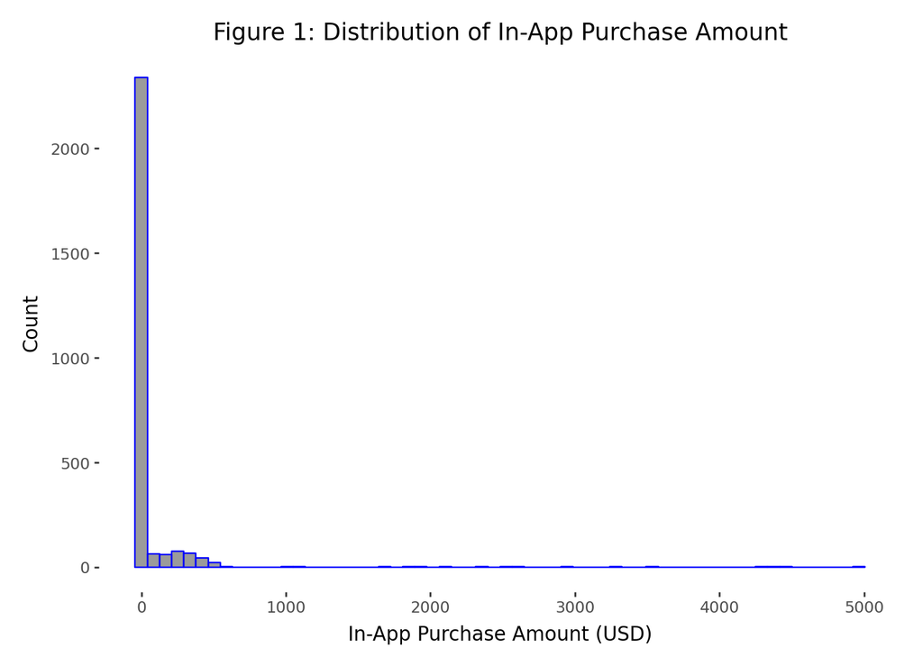

Figure 1: Distribution of raw in-app purchase amounts

```python
g_1 = (
    ggplot(plot_dat, aes(x="InAppPurchaseAmount"))
    + geom_histogram(bins=60, color="blue", alpha=0.6)
    + theme_bw()
    + theme(panel_grid_major=element_blank(), panel_grid_minor=element_blank(),
            panel_border=element_blank(), panel_background=element_blank())
    + labs(title="Figure 1: Distribution of In-App Purchase Amount",
           x="In-App Purchase Amount (USD)", y="Count")
)
display(g_1.draw()); plt.close('all')
```

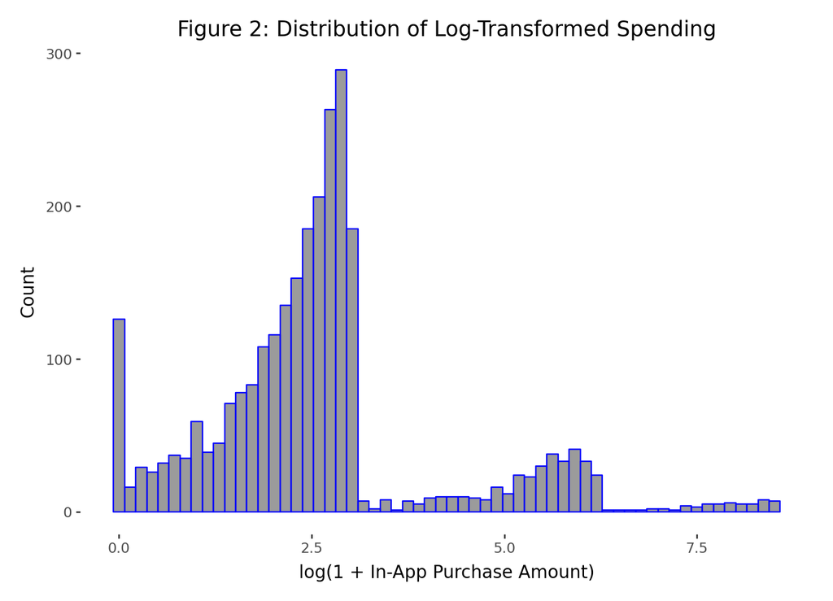

Figure 2: Distribution of log-transformed spending

```python
g_2 = (
    ggplot(plot_dat, aes(x="log_spend"))
    + geom_histogram(bins=60, color="blue", alpha=0.6)
    + theme_bw()
    + theme(panel_grid_major=element_blank(), panel_grid_minor=element_blank(),
            panel_border=element_blank(), panel_background=element_blank())
    + labs(title="Figure 2: Distribution of Log-Transformed Spending",
           x="log(1 + In-App Purchase Amount)", y="Count")
)
display(g_2.draw()); plt.close('all')
```

**Interpretation:** Figures 1 and 2 illustrate the extreme right skew in player spending. In the raw distribution, almost all players spend little or nothing, with a large spike at zero, while a small group drives the majority of revenue. After applying a log transformation, the distribution becomes more symmetric and compact — a necessary step before fitting regression models, which assume a reasonably well-behaved target variable.

### 4.2 Engagement and Spending Relationship

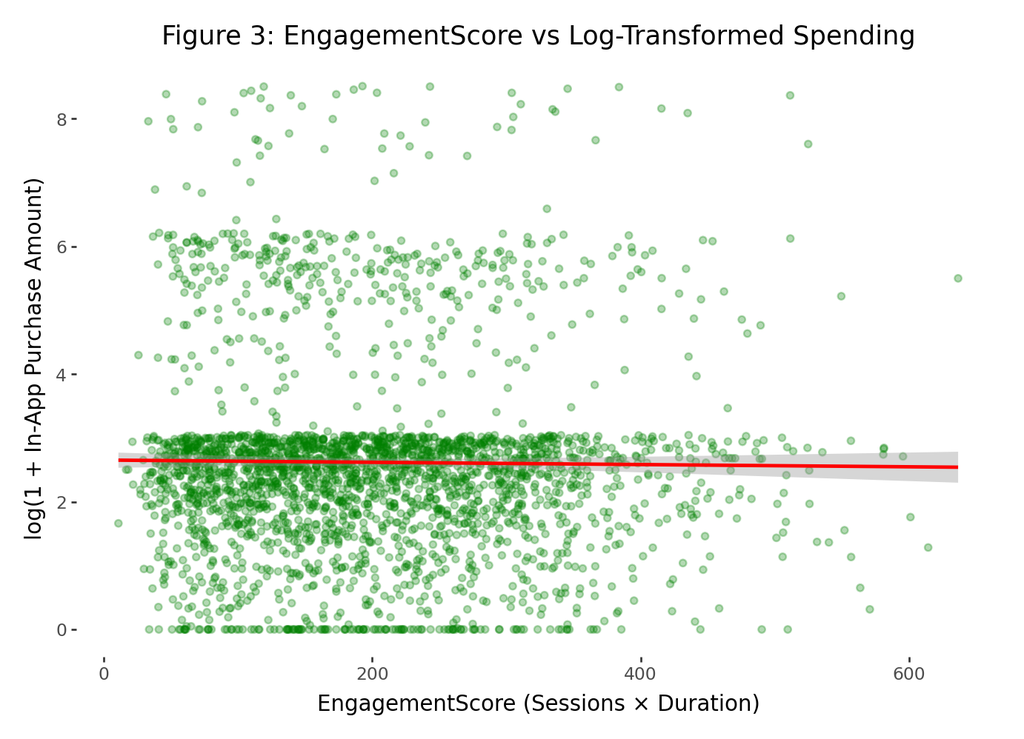

Figure 3: EngagementScore vs log-spending (scatter with regression line)

```python
g_3 = (
    ggplot(plot_dat, aes(x="EngagementScore", y="log_spend"))
    + geom_point(alpha=0.3, color="green")
    + geom_smooth(method="lm", color="red")
    + theme_bw()
    + theme(panel_grid_major=element_blank(), panel_grid_minor=element_blank(),
            panel_border=element_blank(), panel_background=element_blank())
    + labs(title="Figure 3: EngagementScore vs Log-Transformed Spending",
           x="EngagementScore (Sessions × Duration)", y="log(1 + In-App Purchase Amount)")
)
display(g_3.draw()); plt.close('all')
```

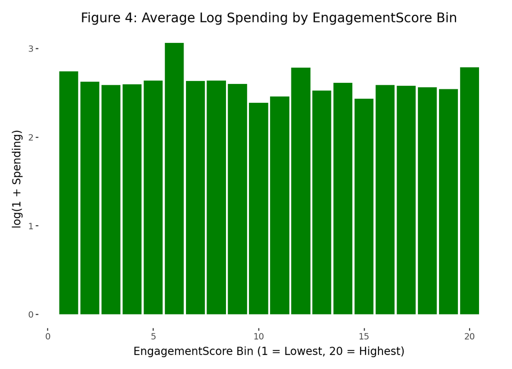

Figure 4: Average log spending across 20 EngagementScore bins

```python
plot_dat['bin'] = pd.qcut(plot_dat['EngagementScore'], 20, labels=False)
df_binned = plot_dat.groupby('bin')['log_spend'].mean().reset_index()
df_binned['bin'] = df_binned['bin'] + 1

g_4 = (
    ggplot(df_binned, aes(x='bin', y='log_spend'))
    + geom_col(fill="green")
    + theme_bw()
    + theme(panel_grid_major=element_blank(), panel_grid_minor=element_blank(),
            panel_border=element_blank(), panel_background=element_blank())
    + labs(title="Figure 4: Average Log Spending by EngagementScore Bin",
           x="EngagementScore Bin (1 = Lowest, 20 = Highest)", y="log(1 + Spending)")
)
display(g_4.draw()); plt.close('all')
```

**Interpretation:** Figures 3 and 4 both point to the same conclusion: **engagement does not strongly predict spending**. Figure 3 shows a nearly flat scatter cloud — many highly engaged players spend little, while some low-engagement players spend a lot. Figure 4 confirms this at the aggregate level: average log-spending remains largely flat across 20 engagement bins, with no clear upward trend. This aligns with findings from Sifa et al. (2015) and Hamari & Lehdonvirta (2010), who note that enjoyment and playtime do not necessarily translate into monetization.

### 4.3 Per-Session Spending Intensity

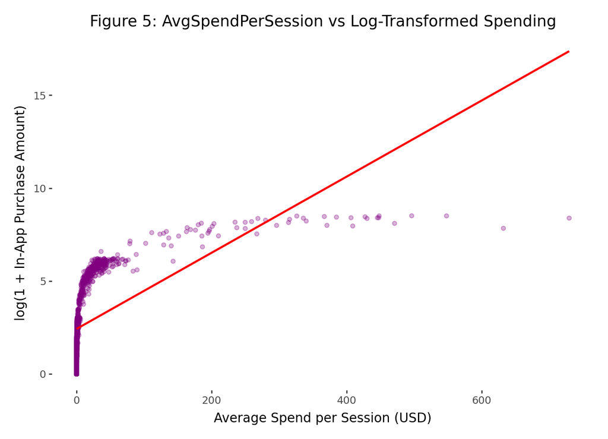

Figure 5: AvgSpendPerSession vs log-spending

```python
g_10 = (
    ggplot(plot_dat, aes(x="AvgSpendPerSession", y="log_spend"))
    + geom_point(alpha=0.3, color="purple")
    + geom_smooth(method="lm", color="red", se=False)
    + theme_bw()
    + theme(panel_grid_major=element_blank(), panel_grid_minor=element_blank(),
            panel_border=element_blank(), panel_background=element_blank())
    + labs(title="Figure 5: AvgSpendPerSession vs Log-Transformed Spending",
           x="Average Spend per Session (USD)", y="log(1 + In-App Purchase Amount)")
)
display(g_10.draw()); plt.close('all')
```

**Interpretation:** Unlike total engagement, per-session spending intensity is strongly and positively associated with total spending. Players who spend more per session tend to become the highest overall spenders. However, because `AvgSpendPerSession` is computed directly from the outcome variable, it is excluded from model training to avoid data leakage. It is shown here only as an exploratory finding.

### 4.4 Spending by Game Genre

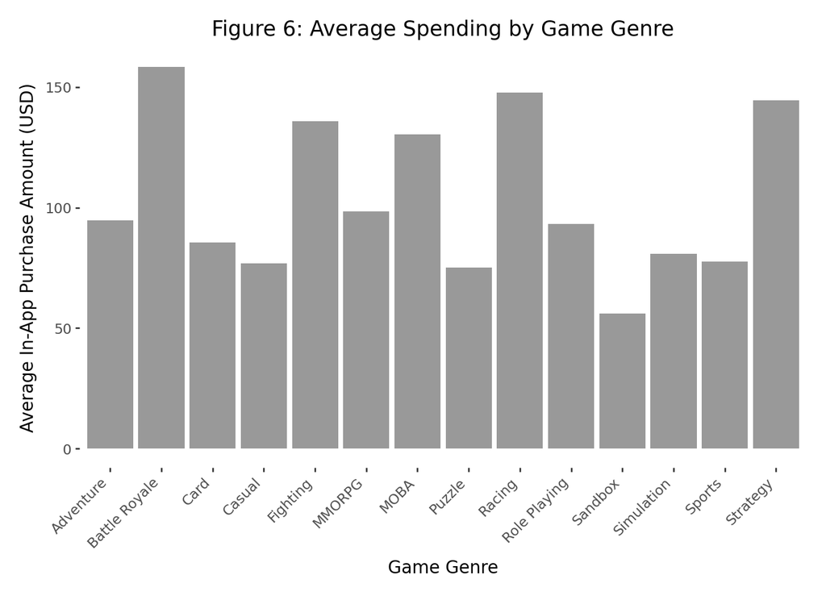

Figure 6: Average spending by game genre

```python
genre_cols = [col for col in df.columns if col.startswith("GameGenre_")]
genre_info = []
for col in genre_cols:
    genre_name = col.replace("GameGenre_", "")
    avg_spend = df[df[col] == 1]['InAppPurchaseAmount'].mean()
    genre_info.append((genre_name, avg_spend))

genre_df = pd.DataFrame(genre_info, columns=["GameGenre", "AvgSpending"]).sort_values(
    by="AvgSpending", ascending=False
)

g_6 = (
    ggplot(genre_df, aes(x="GameGenre", y="AvgSpending"))
    + geom_col(fill="grey", alpha=0.8)
    + theme_bw()
    + theme(panel_grid_major=element_blank(), panel_grid_minor=element_blank(),
            panel_border=element_blank(), panel_background=element_blank(),
            axis_text_x=element_text(rotation=45, hjust=1))
    + labs(title="Figure 6: Average Spending by Game Genre",
           x="Game Genre", y="Average In-App Purchase Amount (USD)")
)
display(g_6.draw()); plt.close('all')
```

**Interpretation:** Spending varies noticeably across game genres. Genres such as Battle Royale, Racing, Strategy, Fighting, and MOBA show the highest average spending — consistent with these genres’ competitive mechanics, progression systems, and monetization structures that encourage repeated purchases.

### 4.5 Spending by Country and Payment Method

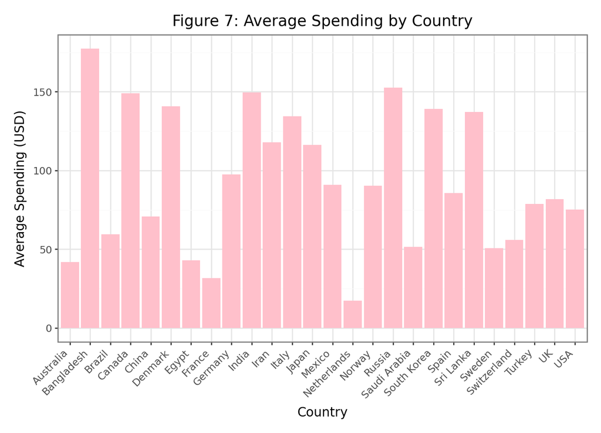

Figure 7: Average spending by country

```python
country_cols = [col for col in df.columns if col.startswith("Country_")]
country_info = []
for col in country_cols:
    country_name = col.replace("Country_", "")
    avg_spend = df[df[col] == 1]['InAppPurchaseAmount'].mean()
    country_info.append((country_name, avg_spend))

country_df = pd.DataFrame(country_info, columns=["Country", "AvgSpending"]).sort_values(
    by="AvgSpending", ascending=False
)

g_8 = (
    ggplot(country_df, aes(x="Country", y="AvgSpending"))
    + geom_col(fill="pink")
    + theme_bw()
    + theme(axis_text_x=element_text(rotation=45, hjust=1))
    + labs(title="Figure 7: Average Spending by Country",
           x="Country", y="Average Spending (USD)")
)
display(g_8.draw()); plt.close('all')
```

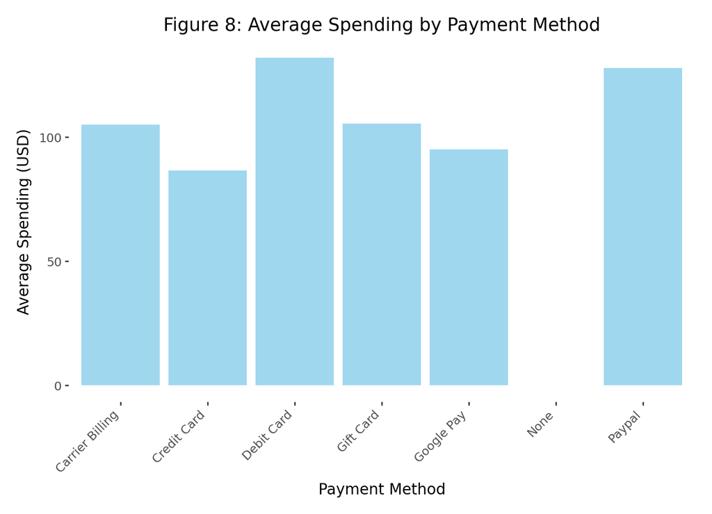

Figure 8: Average spending by payment method

```python
payment_cols = [col for col in df.columns if col.startswith("PaymentMethod_")]
payment_info = []
for col in payment_cols:
    method = col.replace("PaymentMethod_", "")
    avg_spend = df.loc[df[col] == 1, "InAppPurchaseAmount"].mean()
    payment_info.append((method, avg_spend))

payment_df = pd.DataFrame(payment_info, columns=["PaymentMethod", "AvgSpending"]).sort_values(
    by="AvgSpending", ascending=False
)

g_9 = (
    ggplot(payment_df, aes(x="PaymentMethod", y="AvgSpending"))
    + geom_col(fill="skyblue", alpha=0.8)
    + theme_bw()
    + theme(axis_text_x=element_text(rotation=45, hjust=1),
            panel_grid_major=element_blank(), panel_grid_minor=element_blank(),
            panel_border=element_blank(), panel_background=element_blank())
    + labs(title="Figure 8: Average Spending by Payment Method",
           x="Payment Method", y="Average Spending (USD)")
)
display(g_9.draw()); plt.close('all')
```

**Interpretation:** Figures 7 and 8 reveal meaningful variation in spending across geographic and payment-method groups. Countries such as Bangladesh, Canada, Denmark, and India show relatively higher average spending, likely reflecting differences in purchasing power, cultural attitudes toward mobile gaming, and market penetration. Among payment methods, Debit Card and PayPal users spend the most on average. These patterns suggest that demographic and payment context carry some signal for spending — though as the modeling results show, they are not strong individual predictors.

### 4.6 Session Length, Recency, and Player Segmentation

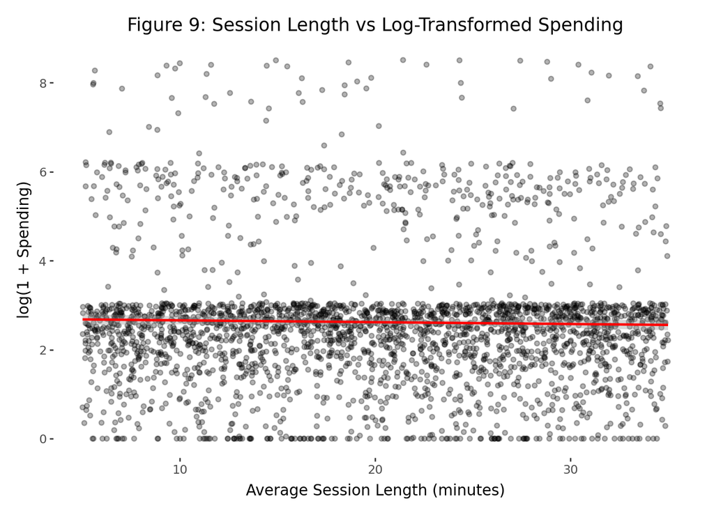

Figure 9: Session length vs log-spending

```python
g_7 = (
    ggplot(plot_dat, aes(x="AverageSessionLength", y="log_spend"))
    + geom_point(alpha=0.3)
    + geom_smooth(method="lm", color="red")
    + theme_bw()
    + theme(panel_grid_major=element_blank(), panel_grid_minor=element_blank(),
            panel_border=element_blank(), panel_background=element_blank())
    + labs(title="Figure 9: Session Length vs Log-Transformed Spending",
           x="Average Session Length (minutes)", y="log(1 + Spending)")
)
display(g_7.draw()); plt.close('all')
```

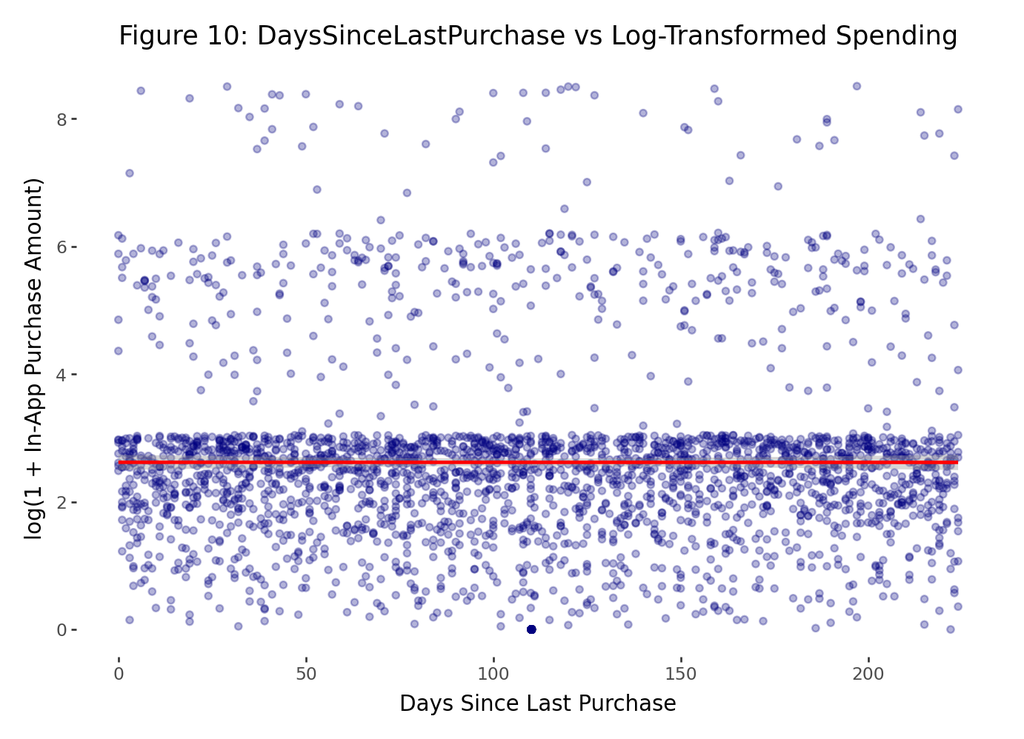

Figure 10: Days since last purchase vs log-spending

```python
g_11 = (
    ggplot(plot_dat, aes(x="DaysSinceLastPurchase", y="log_spend"))
    + geom_point(alpha=0.3, color="navy")
    + geom_smooth(method="lm", color="red")
    + theme_bw()
    + theme(panel_grid_major=element_blank(), panel_grid_minor=element_blank(),
            panel_border=element_blank(), panel_background=element_blank())
    + labs(title="Figure 10: DaysSinceLastPurchase vs Log-Transformed Spending",
           x="Days Since Last Purchase", y="log(1 + In-App Purchase Amount)")
)
display(g_11.draw()); plt.close('all')
```

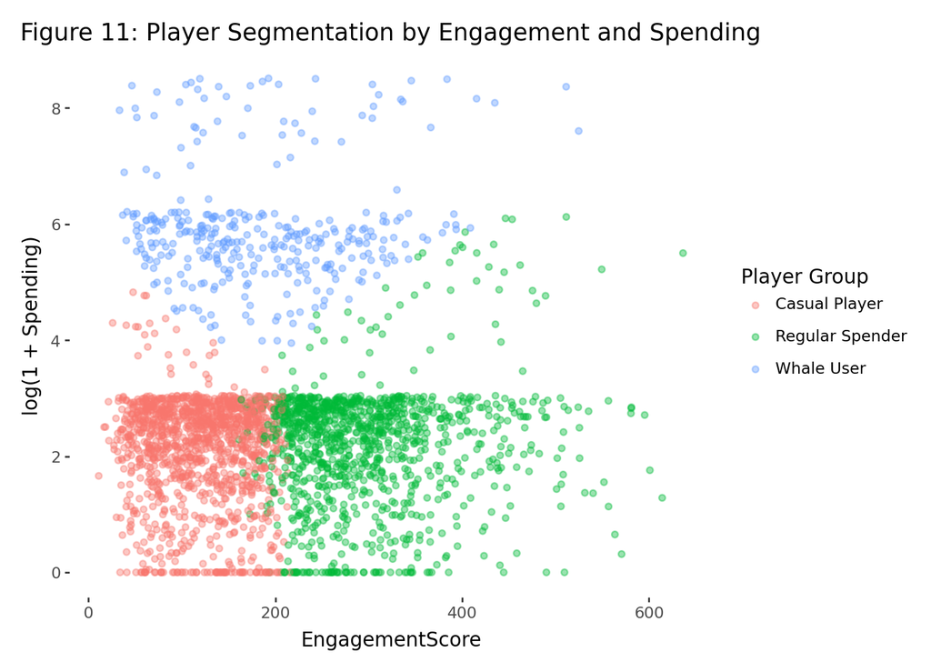

Figure 11: K-means player segmentation by engagement and spending

```python
g_5 = (
    ggplot(df, aes(x='EngagementScore', y='log_spend', color='ClusterLabel'))
    + geom_point(alpha=0.4)
    + theme_bw()
    + theme(panel_grid_major=element_blank(), panel_grid_minor=element_blank(),
            panel_border=element_blank(), panel_background=element_blank())
    + labs(title="Figure 11: Player Segmentation by Engagement and Spending",
           x="EngagementScore", y="log(1 + Spending)", color="Player Group")
)
display(g_5.draw()); plt.close('all')
```

**Interpretation:** Figures 9 and 10 show that both session length and purchase recency have very weak linear relationships with spending. The regression lines are essentially flat, and the scatter clouds show no systematic pattern. This is somewhat surprising, since recency is widely cited in the CRM literature, but it is consistent with the overall theme: individual spending in this dataset is noisy and hard to predict from behavioral metrics alone.

## 5. Modeling Setup

### 5.1 Feature Matrix and Target Variable

```python
# Feature matrix: exclude outcome and leakage variables
X = df.drop(
    columns=['InAppPurchaseAmount', 'log_spend', 'Cluster', 'ClusterLabel',
             'AvgSpendPerSession', 'Whale', 'SpendingSegment'],
    errors='ignore'
)
X = X.select_dtypes(include=[np.number])

# Regression target: log-transformed spending
y = df['log_spend']

# 80/20 train/test split
X_train, X_test, y_train, y_test = train_test_split(
    X, y, test_size=0.2, random_state=42
)

print(f"Feature matrix: {X.shape[0]} rows × {X.shape[1]} features")
print(f"Training set: {X_train.shape[0]} samples | Test set: {X_test.shape[0]} samples")
```

```
Feature matrix: 2733 rows × 56 features
Training set: 2186 samples | Test set: 547 samples
```

The final feature matrix includes **56 numeric predictors** after one-hot encoding. `AvgSpendPerSession` and `SpendingSegment` are excluded to prevent data leakage. The target is `log_spend` — the log-transformed in-app purchase amount.

All models are trained on 80% of the data (~2,186 samples) and evaluated on the held-out 20% (~547 samples).

## 6. Regression Models

### 6.1 Linear Regression (Baseline)

```python
lr = LinearRegression()
lr.fit(X_train, y_train)
y_pred_lr = lr.predict(X_test)

lr_mae  = mean_absolute_error(y_test, y_pred_lr)
lr_rmse = np.sqrt(mean_squared_error(y_test, y_pred_lr))
lr_r2   = r2_score(y_test, y_pred_lr)

print(f"Linear Regression  |  MAE: {lr_mae:.4f}  |  RMSE: {lr_rmse:.4f}  |  R²: {lr_r2:.4f}")
```

```
Linear Regression  |  MAE: 0.9751  |  RMSE: 1.4504  |  R²: 0.0525
```

The baseline linear regression explains only about **5% of the variance** in log-spending (R² ≈ 0.053), confirming that spending behavior does not follow simple linear patterns relative to the available features.

### 6.2 Lasso Regression (Regularized Linear)

```python
scaler_lasso = StandardScaler()
X_train_scaled = scaler_lasso.fit_transform(X_train)
X_test_scaled  = scaler_lasso.transform(X_test)

alpha_grid = np.logspace(-4, 1, 50)
lasso_cv = LassoCV(alphas=alpha_grid, cv=5, random_state=42)
lasso_cv.fit(X_train_scaled, y_train)

y_pred_lasso = lasso_cv.predict(X_test_scaled)

lasso_mae  = mean_absolute_error(y_test, y_pred_lasso)
lasso_rmse = np.sqrt(mean_squared_error(y_test, y_pred_lasso))
lasso_r2   = r2_score(y_test, y_pred_lasso)

print(f"Best α (λ): {lasso_cv.alpha_:.6f}")
print(f"Lasso Regression   |  MAE: {lasso_mae:.4f}  |  RMSE: {lasso_rmse:.4f}  |  R²: {lasso_r2:.4f}")
```

```
Best α (λ): 0.044984
Lasso Regression   |  MAE: 0.9309  |  RMSE: 1.4133  |  R²: 0.1004
```

```python
coef_series = pd.Series(lasso_cv.coef_, index=X_train.columns)
selected = coef_series[coef_series != 0].sort_values(ascending=False)
print(f"\nNon-zero Lasso coefficients ({len(selected)} selected):")
print(selected.round(4))
```

```
Non-zero Lasso coefficients (16 selected):
Country_Bangladesh               0.0418
Country_India                    0.0250
GameGenre_Racing                 0.0171
GameGenre_Fighting               0.0123
GameGenre_Adventure              0.0105
PaymentMethod_Debit Card         0.0081
Country_Sri Lanka                0.0051
Country_Sweden                   0.0035
FirstPurchaseDaysAfterInstall    0.0035
Country_Australia               -0.0009
Country_Switzerland             -0.0041
AverageSessionLength            -0.0058
Country_France                  -0.0161
Country_Spain                   -0.0206
Country_Netherlands             -0.0277
PaymentMethod_None              -0.5317
dtype: float64
```

**Interpretation:** Lasso regression, tuned via 5-fold cross-validation, achieves the best R² among all models at approximately **0.10**. Lasso shrinks most coefficients to zero, retaining primarily country indicators and payment-method dummies while eliminating many behavioral features. This confirms that even the most informative linear signals are weak: the dominant predictors in the Lasso solution are categorical location and payment attributes rather than engagement metrics.

### 6.3 Decision Tree Regressor

```python
num_cols_dt = X_train.columns.tolist()

preprocess_pipe = Pipeline([
    ("imputer", SimpleImputer(strategy="median")),
    ("scaler", StandardScaler())
])

X_train_dt_trans = preprocess_pipe.fit_transform(X_train)
X_test_dt_trans  = preprocess_pipe.transform(X_test)

tree_reg = DecisionTreeRegressor(max_depth=4, random_state=42)
tree_reg.fit(X_train_dt_trans, y_train)

y_pred_dt = tree_reg.predict(X_test_dt_trans)

dt_mae  = mean_absolute_error(y_test, y_pred_dt)
dt_rmse = np.sqrt(mean_squared_error(y_test, y_pred_dt))
dt_r2   = r2_score(y_test, y_pred_dt)

print(f"Decision Tree      |  MAE: {dt_mae:.4f}  |  RMSE: {dt_rmse:.4f}  |  R²: {dt_r2:.4f}")
```

```
Decision Tree      |  MAE: 0.9377  |  RMSE: 1.4335  |  R²: 0.0745
```

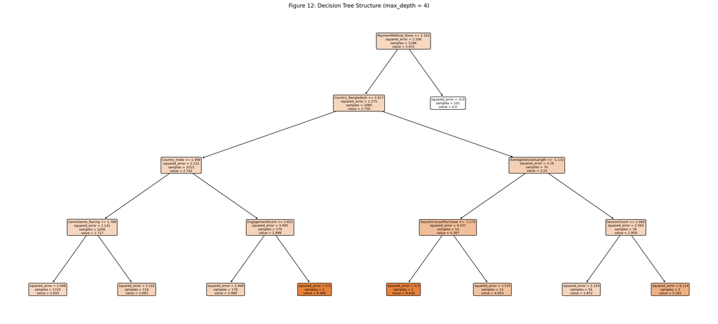

Figure 12: Decision tree structure (max_depth = 4)

```python
plt.figure(figsize=(22, 10))
plot_tree(
    tree_reg,
    feature_names=num_cols_dt,
    filled=True,
    fontsize=7,
    rounded=True
)
plt.title("Figure 12: Decision Tree Structure (max_depth = 4)")
plt.tight_layout()
plt.show()
```

**Interpretation:** The decision tree (R² ≈ 0.075) explains slightly more variance than linear regression, capturing some nonlinear patterns. Inspection of the tree structure reveals a clear hierarchy of splits: the root splits on `PaymentMethod_None`, separating players without a stored payment method from those with one. Subsequent splits branch on country indicators (Bangladesh, India) and then on behavioral variables (EngagementScore, DaysSinceLastPurchase, SessionCount). This layered structure is interpretable and meaningful — payment readiness and geography matter most at the top-level segmentation.

### 6.4 Random Forest Regressor

```python
X_train_rf_trans = preprocess_pipe.transform(X_train)
X_test_rf_trans  = preprocess_pipe.transform(X_test)

rf_reg = RandomForestRegressor(n_estimators=300, max_depth=None, random_state=42, n_jobs=-1)
rf_reg.fit(X_train_rf_trans, y_train)

y_pred_rf = rf_reg.predict(X_test_rf_trans)

rf_mae  = mean_absolute_error(y_test, y_pred_rf)
rf_rmse = np.sqrt(mean_squared_error(y_test, y_pred_rf))
rf_r2   = r2_score(y_test, y_pred_rf)

print(f"Random Forest      |  MAE: {rf_mae:.4f}  |  RMSE: {rf_rmse:.4f}  |  R²: {rf_r2:.4f}")
```

```
Random Forest      |  MAE: 1.0100  |  RMSE: 1.4576  |  R²: 0.0431
```

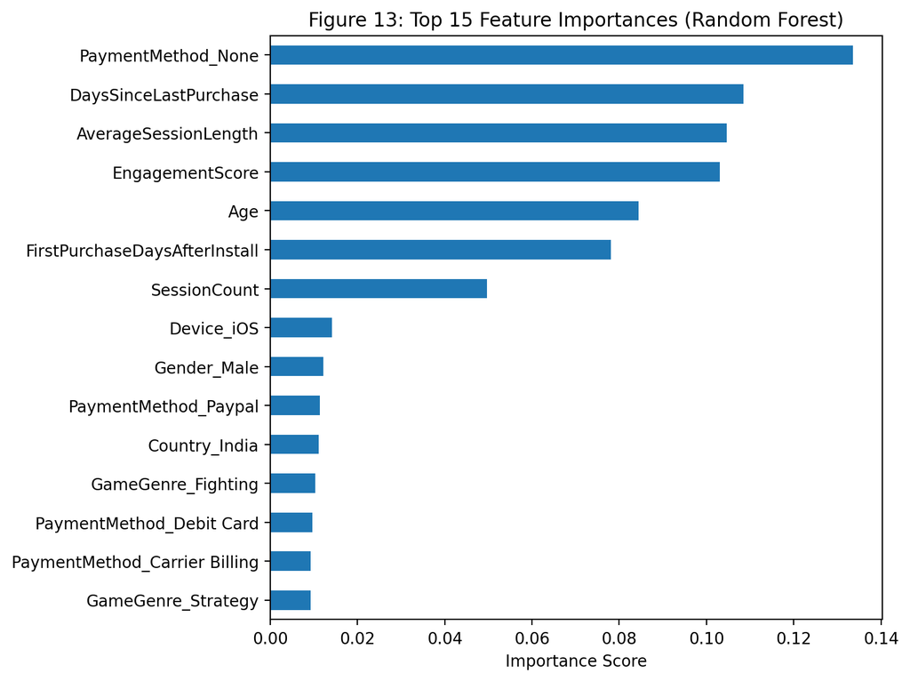

Figure 13: Top 15 feature importances from the Random Forest model

```python
rf_importance = pd.Series(
    rf_reg.feature_importances_, index=num_cols_dt
).sort_values(ascending=False)

plt.figure(figsize=(8, 6))
rf_importance.head(15).plot(kind='barh')
plt.title("Figure 13: Top 15 Feature Importances (Random Forest)")
plt.xlabel("Importance Score")
plt.gca().invert_yaxis()
plt.tight_layout()
plt.show()
```

### 6.5 XGBoost Regressor

#### Training and Test Performance

```python
dtrain = xgb.DMatrix(data=X_train.values, label=y_train.values)
dtest  = xgb.DMatrix(data=X_test.values,  label=y_test.values)

params = {
    "objective": "reg:squarederror",
    "eta": 0.10,
    "max_depth": 6,
    "subsample": 0.8,
    "colsample_bytree": 0.8,
    "eval_metric": ["rmse"],
    "seed": 42,
}

booster = xgb.train(
    params=params,
    dtrain=dtrain,
    num_boost_round=300,
    evals=[(dtrain, "train")],
    verbose_eval=50
)

y_pred_xgb = booster.predict(dtest)

xgb_mae  = mean_absolute_error(y_test, y_pred_xgb)
xgb_rmse = np.sqrt(mean_squared_error(y_test, y_pred_xgb))
xgb_r2   = r2_score(y_test, y_pred_xgb)

print(f"XGBoost            |  MAE: {xgb_mae:.4f}  |  RMSE: {xgb_rmse:.4f}  |  R²: {xgb_r2:.4f}")
```

```
XGBoost            |  MAE: 1.1533  |  RMSE: 1.5832  |  R²: -0.1288
```

#### Cross-Validation: Selecting Optimal Iterations

```python
cv_params = {**params, "eval_metric": "rmse"}

cv_res = xgb.cv(
    params=cv_params,
    dtrain=dtrain,
    num_boost_round=400,
    nfold=5,
    verbose_eval=20,
    shuffle=True
)

best_idx  = cv_res['test-rmse-mean'].idxmin()
best_iter = best_idx + 1
best_rmse = float(cv_res.loc[best_idx, 'test-rmse-mean'])

print(f"Best iteration: {best_iter}  |  Minimum CV test RMSE: {best_rmse:.6f}")
```

```
Best iteration: 14  |  Minimum CV test RMSE: 1.498852
```

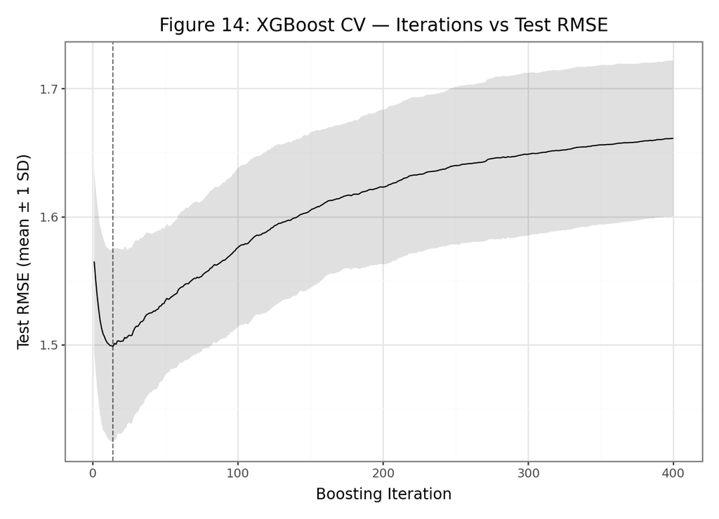

Figure 14: XGBoost cross-validation: RMSE vs boosting iterations

```python
df_plot = cv_res.reset_index().rename(columns={"index": "iter"})
df_plot["iter"] += 1
df_plot = df_plot.rename(columns=lambda c: c.replace("-", "_"))
df_plot["rmse_lower"] = df_plot["test_rmse_mean"] - df_plot["test_rmse_std"]
df_plot["rmse_upper"] = df_plot["test_rmse_mean"] + df_plot["test_rmse_std"]

p_rmse = (
    ggplot(df_plot, aes(x="iter", y="test_rmse_mean"))
    + geom_line()
    + geom_ribbon(aes(ymin="rmse_lower", ymax="rmse_upper"), alpha=0.15)
    + geom_vline(xintercept=best_iter, linetype="dashed", alpha=0.6)
    + theme_bw()
    + labs(title="Figure 14: XGBoost CV — Iterations vs Test RMSE",
           x="Boosting Iteration", y="Test RMSE (mean ± 1 SD)")
)
display(p_rmse.draw()); plt.close('all')
```